# Reproducible Research: Project1

Chad Burdyshaw

Friday, July 11, 2014

=====================================

### Loading and preprocessing the data

```r
activity <- read.csv("activity.csv",stringsAsFactors=FALSE)
#convert date factor to date
activity$date<-as.Date(activity$date,format="%Y-%m-%d")
```

```r
#calculate total steps per day
# Sum the total number of steps for each day
dailytotal=tapply(activity$steps,activity$date,sum)
```

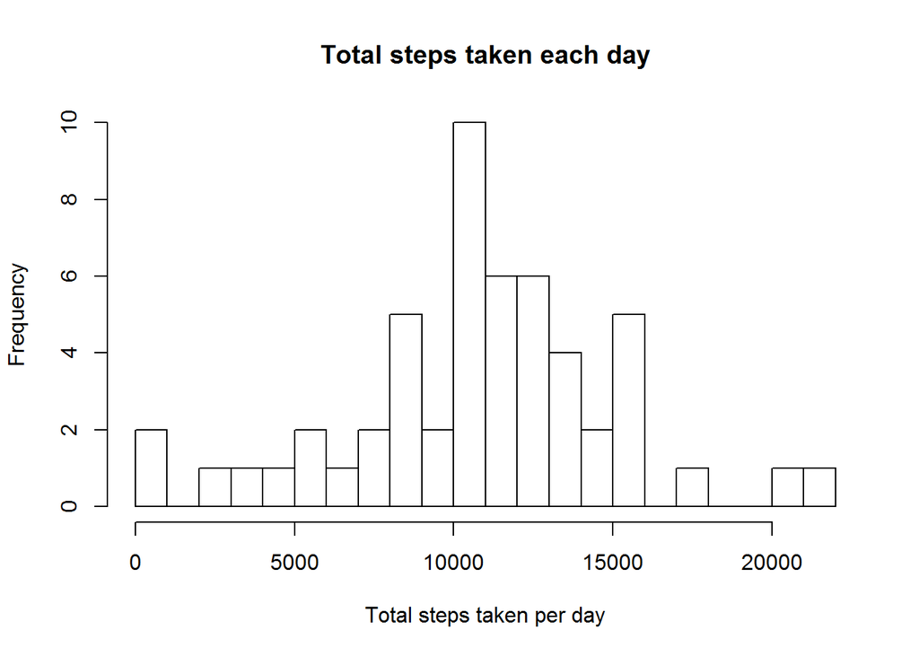

```r
#make histogram of total number of steps taken each day
dailytotal_hist=hist(dailytotal,xlab="Total steps taken per day",breaks=20,main="Total steps taken each day")
```

```r
#calculate and report mean and median total number of steps taken per day
mean.orig<-mean(dailytotal,na.rm=TRUE)
median.orig<-median(dailytotal,na.rm=TRUE)
```

The mean and medial total number of steps taken per day are 1.0766 × 10<sup>4</sup> and 10765 respectively.

### What is the average daily activity pattern?

```r
#compute total and mean step counts for each interval and add them to a data set
activity_interval <-ddply(activity,"interval",transform,totsteps=sum(steps,na.rm=TRUE),avgsteps=mean(steps,na.rm=TRUE))
#remove duplicated interval values
interval_sub=subset(activity_interval,!duplicated(interval))
```

```r
#locate 5 min interval on average across all the days in the dataset, which contains the maximum number of steps.
point.index=which(interval_sub$totsteps==max(interval_sub$totsteps))
interval=interval_sub$interval[point.index]
maxsteps=interval_sub$avgsteps[point.index]
```

Plot of interval average of steps across all days in the data set. Maximum average steps occurs at point indicated by the red dot at interval 835

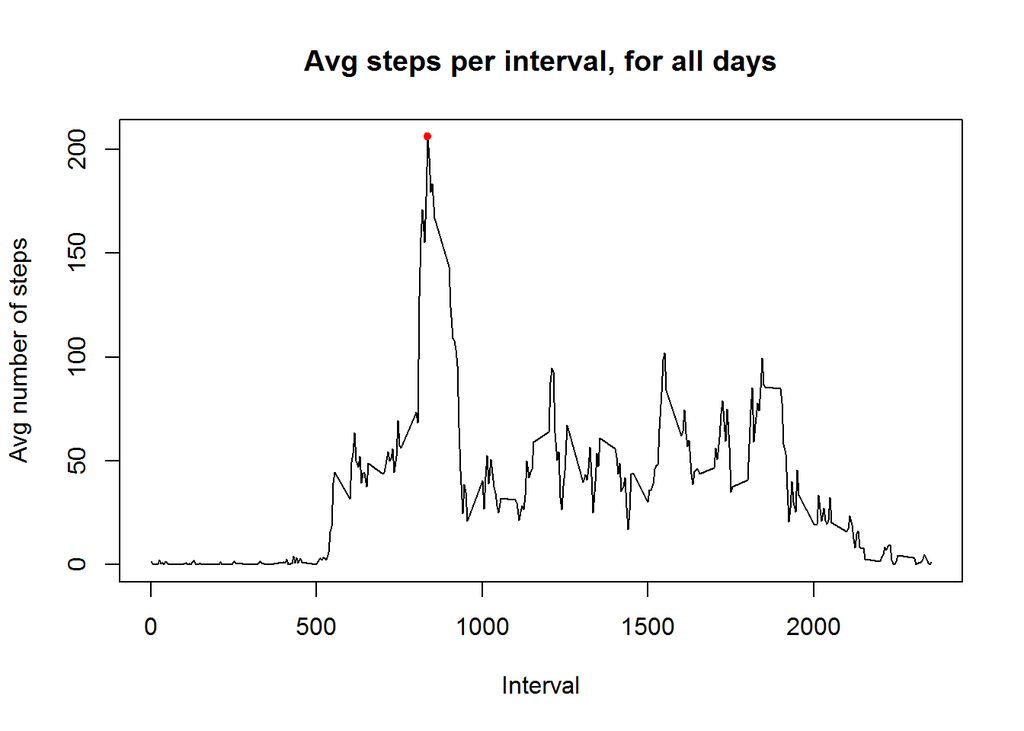

```r
plot(x=interval_sub$interval,y=interval_sub$avgsteps,type="l",xlab="Interval",ylab="Avg number of steps",main="Avg steps per interval, for all days")
#add point to plot marking the max average step and interval
points(interval,maxsteps,col="red",pch=20)
```

### Imputing missing values

The presence of missing values in a data set introduces a bias towards the recorded values in the analysis of the data.

```r
#calculate and report the total number of missing values in the dataset (total number of rows with NA's)
#summary(activity)
#missing values only in the steps field
#sum(is.na(activity$steps))
n.missingVals=sum(!complete.cases(activity))
```

The total number of missing values in the original data set is 2304

In order to address this missing value bias, we can judiciously impute values that would likely have been recorded.

There are several ways to impute values, which can introduce their own biases.

I have decided to investigate two simple imputation methods. One which simply replaces the missing values with the mean of the existing values, and another which replaces each missing value with a random sampling of the existing values.

```r
#function to replace missing values with the mean of existing values
mean.imp<-function(a){
    missing<-is.na(a)
    n.missing<-sum(missing)
    a.obs<-a[!missing]
    imputed<-a
    imputed[missing]<-mean(a.obs,na.rm=TRUE)
    return(imputed)
}
#function to replace missing values with a random sample of existing values
random.imp<-function(a){
    missing<-is.na(a)
    n.missing<-sum(missing)
    a.obs<-a[!missing]
    imputed<-a
    imputed[missing]<-sample(a.obs,n.missing,replace=TRUE)
    return(imputed)
}

#Create a new dataset that is equal to the original dataset but with the missing data filled in.

#replace with the mean
activity.mean.imp<-activity
activity.mean.imp$steps<-mean.imp(activity$steps)

#random replacement
set.seed(144)
activity.rand.imp<-activity
activity.rand.imp$steps<-random.imp(activity$steps)
```

### Analysis of total steps taken per day for imputed data sets

```r
#sum data with random imputations
dailytotal.rand.imp=tapply(activity.rand.imp$steps,activity.rand.imp$date,sum)

#sum data with mean imputation
dailytotal.mean.imp=tapply(activity.mean.imp$steps,activity.mean.imp$date,sum)
```

Imputing to the mean significantly skews the data towards the mean

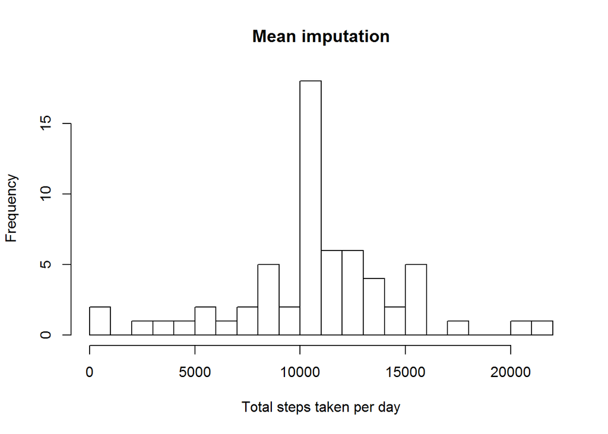

```r
#make histogram of total number of steps taken each day for mean imputation
dailytotal.mean.imp_hist=hist(dailytotal.mean.imp,xlab="Total steps taken per day",breaks=20,main="Mean imputation")
```

```r
mean.mean.imp<-mean(dailytotal.mean.imp,na.rm=TRUE)
median.mean.imp<-median(dailytotal.mean.imp,na.rm=TRUE)
```

The mean and median values of the mean imputed data set are 1.0766 × 10<sup>4</sup> and 1.0766 × 10<sup>4</sup> respectively.

Imputing using random sampling produces a distribution which is similar in shape to the original data set

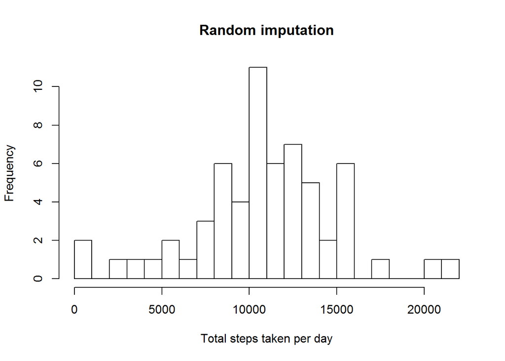

```r
#make histogram of total number of steps taken each day for random imputation
dailytotal.rand.imp_hist=hist(dailytotal.rand.imp,xlab="Total steps taken per day",breaks=20,main="Random imputation")
```

```r
#calculate and report mean and median total number of steps taken per day
mean.rand.imp<-mean(dailytotal.rand.imp,na.rm=TRUE)
median.rand.imp<-median(dailytotal.rand.imp,na.rm=TRUE)
```

The mean and median values of the randomly imputed data set are 1.0779 × 10<sup>4</sup> and 10765 respectively.

Do these values differ from the estimates from the first part of the assignment?

```r
#with mean imputation, only the mean value is added so the mean remains constant
#and the median shifts slightly
rel.mean.mean.error<-abs(mean.orig-mean.mean.imp)/mean.orig
rel.median.mean.error<-abs(median.orig-median.mean.imp)/median.orig
```

The relative error between the original and mean imputed data is: mean error=0 and median error=1.1042 × 10<sup>-4</sup>

```r
#with random imputation many different values are added, so the mean is shifted
#the median remains constant
rel.mean.rand.error<-abs(mean.orig-mean.rand.imp)/mean.orig
rel.median.rand.error<-abs(median.orig-median.rand.imp)/median.orig
```

The relative error between the original and randomly imputed data is: mean error=0.0012 and median error=0

### What is the impact of imputing missing data on the estimates of the total daily number of steps?

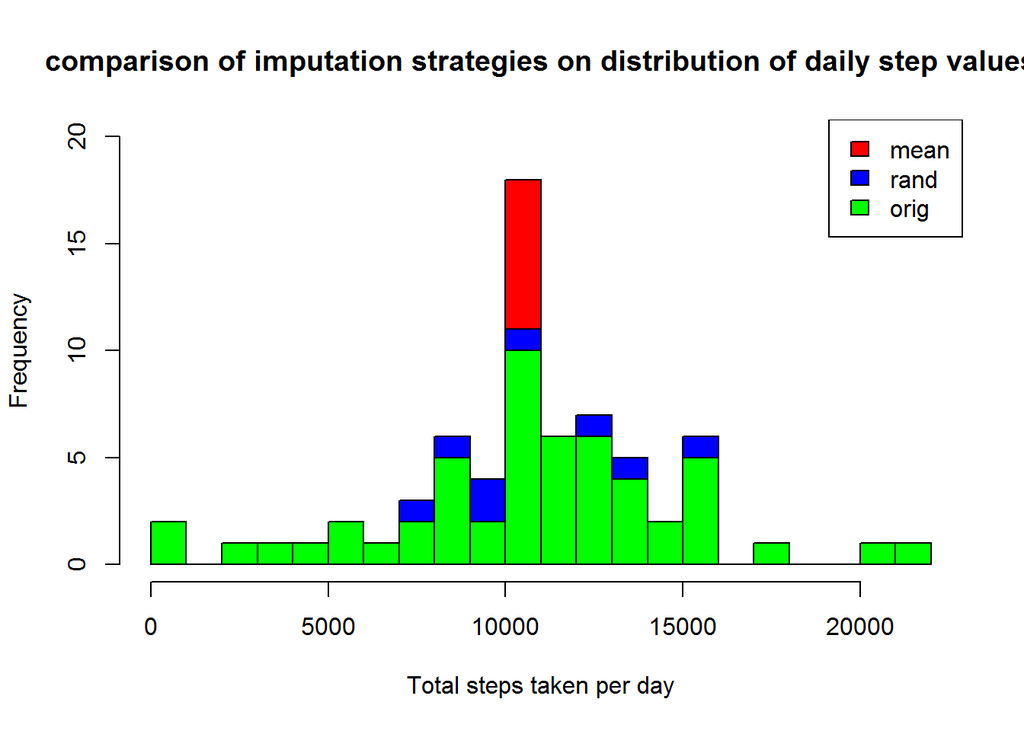

```r
#overlay histograms
dailytotal.mean.imp_hist=hist(dailytotal.mean.imp,col=rgb(1,0,0,1),xlab="Total steps taken per day",breaks=20,ylim=c(0,20),main="comparison of imputation strategies on distribution of daily step values")
dailytotal.rand.imp_hist=hist(dailytotal.rand.imp,col=rgb(0,0,1,1),breaks=20,add=T)
dailytotal_hist=hist(dailytotal,col=rgb(0,1,0,1),breaks=20,add=T)
legend("topright",c("mean","rand","orig"),fill=c(rgb(1,0,0,1),rgb(0,0,1,1),rgb(0,1,0,1)))
```

From the histogram overlay we can see that a mean imputation largely overestimates the frequency of the mean. The random imputation slightly raises the value of the mean but retains a similar frequency distribution as the original data.

### Are there differences in activity patterns between weekdays and weekends?

Compute average steps per interval separated by weekday and weekend

```r
#Create a new factor variable in the dataset with two levels - "weekday" and "weekend" indicating whether a given date is a weekday or weekend.
daytype.classify<-function(a){
    a.day=weekdays(a)
    weekend=which(a.day=="Saturday" | a.day=="Sunday")
    a.n=length(a)
    dayType<-c(rep(0,a.n))
    dayType[weekend] <- 1
    dayType=as.factor(dayType)
    levels(dayType)<-c("Weekday","Weekend")
    return(dayType)
}
#apply function to create new dataset variable
activity.rand.imp$dayType<-daytype.classify(activity.rand.imp$date)
```

Plot of time series of the 5-minute interval (x-axis) and the average number of steps taken, averaged across all weekday days or weekend days (y-axis).

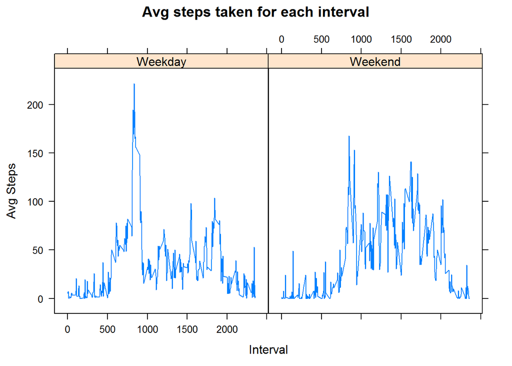

```r
#compute average and total over intervals for each dayType independently
interval_data<-summaryBy(steps~interval|dayType,data=activity.rand.imp,FUN=c(sum,mean),na.rm=TRUE)
#plot interval data
xyplot(steps.mean~interval|dayType,data=interval_data,type="l",xlab="Interval",ylab="Avg Steps",main="Avg steps taken for each interval")
```

The activity pattern for weekdays differs somewhat from the weekend. Weekend data shows a later onset of activity suggesting the subject sleeps in longer on the weekends and is more physically active throughout the remainder of the weekend.

The weekday pattern shows a spike of activity at the beginning of the day followed by low activity for the remainder. This suggests either a morning workout routine or physical commute to a job that does not involve much activity.